# STAT 428: Homework 6 Solution: Chapter 8 and 9 and Optimization

Was due Week 14 Saturday, December 1 by 11.59 PM on Compass

Please refer to the [**detailed homework policy document**](https://compass2g.illinois.edu/bbcswebdav/pid-3348982-dt-content-rid-35374883_1/courses/stat_428_120188_166591/1_Info/Syllabus/homework_policy.html) on Course Page for information about homework formatting, submission, and grading. Additional policies:

1. Whenever you are asked about an algorithm or a code implementing such, you have to either explain the algorithm clearly in steps or provide detailed documentation/comments on your R code explaining what you are doing. This is to ensure we fully understand what your code is trying to achieve since it can be hard to depict codes sometimes.
2. When using an R code chunk in the RmD with {r}, please use {r,eval=TRUE, echo=TRUE, include=TRUE} instead so that your chunk and results show in the html. This is just to help us grade faster.
3. When using external packages, please mention clearly what R packages you are using so that we can install those when running your codes. Furthermore, please call the package in your code using the “library” function so that your code shows no error when running.

## Solution to Exercise 1

**Maximum Likelihood Estimator** Suppose that $X$ is a discrete random variable with

- $\mathbb{P}(X= 0) = \displaystyle\frac{1}{4} \theta$;
- $\mathbb{P}(X= 1) = \displaystyle\frac{3}{4} \theta$;
- $\mathbb{P}(X= 2) = \displaystyle\frac{1}{4} (1-\theta)$;
- $\mathbb{P}(X= 3) = \displaystyle\frac{3}{4} (1-\theta)$;

where $0 \le \theta \le 1$ is a parameter. The following 10 independent observations were taken from such a distribution: $(3,0,2,1,3,2,1,0,2,1)$. *(Hint: For R code it may help to refer to maximumLikelihood.R in Class Materials on compass.)*

**(a)** What is the likelihood function $L(\theta$) for the sample $(3,0,2,1,3,2,1,0,2,1)$?

For $x=(3,0,2,1,3,2,1,0,2,1)$

$$\begin{eqnarray}
L(\theta)&=f(0,\theta)^2 + f(1,\theta)^3 + f(2,\theta)^3 + f(3,\theta)^2 \\
&=\left(\displaystyle\frac{1}{4}\theta\right)^2 \cdot\left(\displaystyle\frac{3}{4}\theta\right)^3 \cdot \left(\displaystyle\frac{1}{4}(1-\theta)\right)^3 \cdot
\left(\displaystyle\frac{3}{4}(1-\theta)\right)^2\\
&=\left(\displaystyle\frac{1}{4}\right)^5 \cdot
\left(\displaystyle\frac{3}{4}\right)^5 \cdot
\left(\theta\right)^5 \cdot
\left((1-\theta)\right)^5
\end{eqnarray}$$

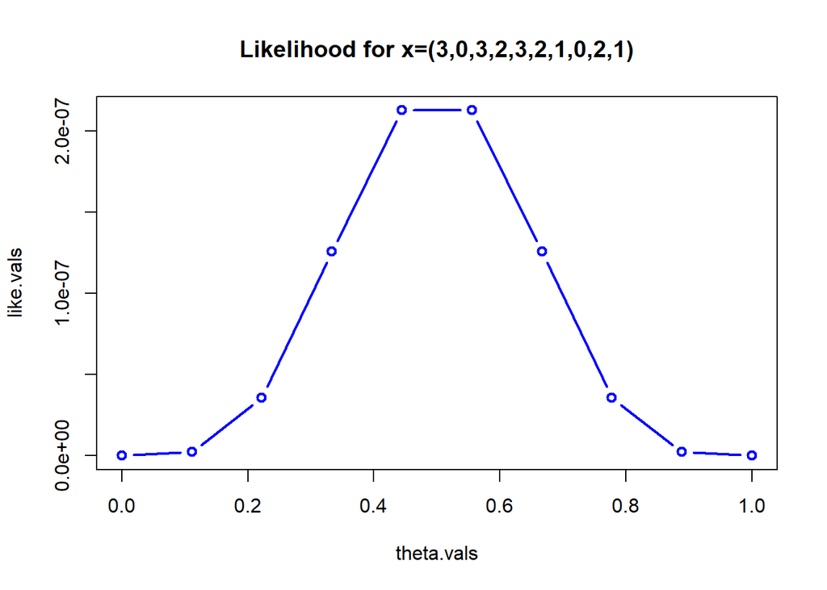

```r
# likelihood
# x = (3,0,3,2,3,2,1,0,2,1)
x <- c(3,0,3,2,3,2,1,0,2,1)
# Note this is not robust, it does not calculate for any x
likelihood.exercise = function(theta) {
  # theta   parameter
  ans = (1/4)^5*(3/4)^5*theta^5 * (1-theta)^5
  return(ans)
}

# plot likelihood
theta.vals = seq(0,1, length.out=10)
like.vals = likelihood.exercise(theta.vals)
plot(theta.vals, like.vals, type="b", col="blue", lwd=2,
     main="Likelihood for x=(3,0,3,2,3,2,1,0,2,1)")
```

**(b)** What is the log-likelihood function $l(\theta$) for the sample $(3,0,2,1,3,2,1,0,2,1)$?

For $x=(3,0,2,1,3,2,1,0,2,1)$, the likelihood function is

$$\begin{eqnarray}
L(\theta)&=\left(\displaystyle\frac{1}{4}\right)^5 \cdot
\left(\displaystyle\frac{3}{4}\right)^5 \cdot
\left(\theta\right)^5 \cdot
\left((1-\theta)\right)^5
\end{eqnarray}$$

So, the log likelihood is

$$\begin{eqnarray}
l(\theta)&=log(L(\theta))\\
&= 5 log\displaystyle\frac{1}{4}+ 5 log\displaystyle\frac{3}{4} + 5 log(\theta) + + 5 log(1- \theta)
\end{eqnarray}$$

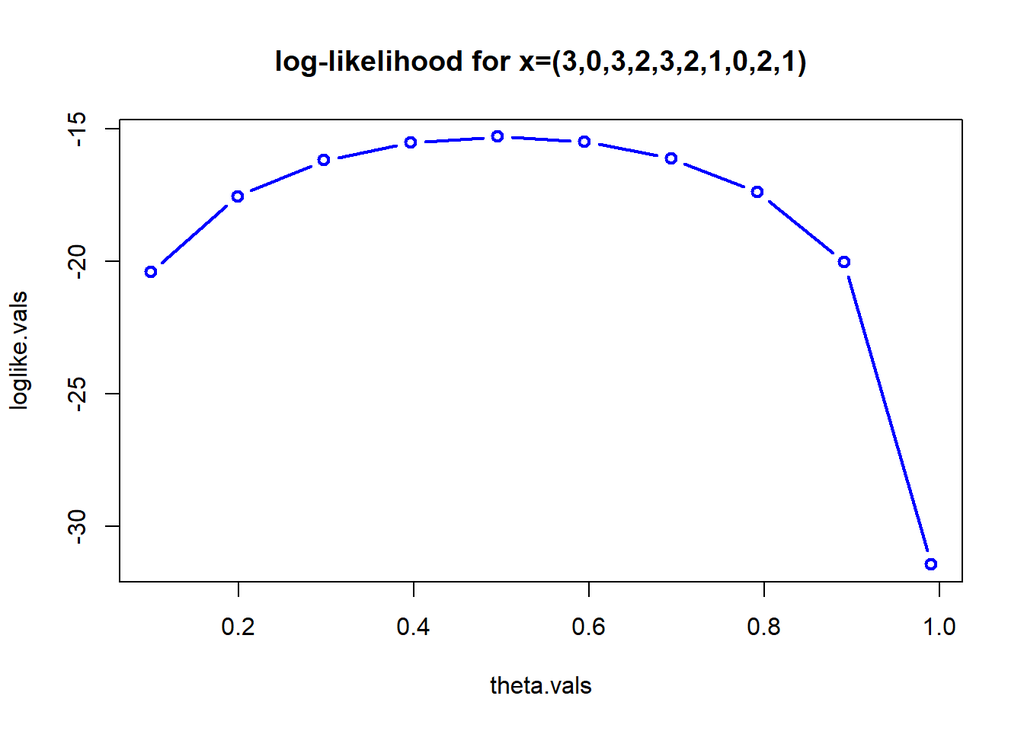

```r
#
# log-likelihood functions
#

loglike.exercise = function(theta) {
  # theta   parameter
  ans = (5*log(1/4) + 5*log(3/4)+ 5*log(theta)+5*log(1-theta))
  return(ans)
}

# plot log-likelihood
#par(mfrow=c(1,2))
theta.vals = seq(0.1,0.99, length.out=10)
loglike.vals = loglike.exercise(theta.vals)
plot(theta.vals, loglike.vals, type="b", col="blue", lwd=2,
     main="log-likelihood for x=(3,0,3,2,3,2,1,0,2,1)")
```

**(c)** What is the maximum log-likelihood estimate of $\theta$? *(Hint: Recall the `optimize` function in R.)*

$$\begin{eqnarray}
l'(\theta)&=\displaystyle\frac{5}{\theta}- \displaystyle\frac{5}{1-\theta};\\
l''(\theta)&=-\displaystyle\frac{5}{\theta^2}- \displaystyle\frac{5}{(1-\theta)^2}<0;\\
\end{eqnarray}$$
So, $l(\frac{1}{2}) = \max_{0\leq\theta\leq1} l(\theta)$ So, in this case MLE is $\tilde{\theta} = \frac{1}{2}$.

Now, we can use either optimize to maximize the log likelihood function or use the maxLik package directly. Both result in a MLE = $0.5$.Notice the maxLik package output has more details.

```r
# optimize() function
ans = optimize(loglike.exercise, lower=-1, upper=1, maximum=TRUE)
class(ans)
```

```
## [1] "list"
```

```r
names(ans)
```

```
## [1] "maximum"   "objective"
```

```r
ans
```

```
## $maximum
## [1] 0.5
##
## $objective
## [1] -15.3
```

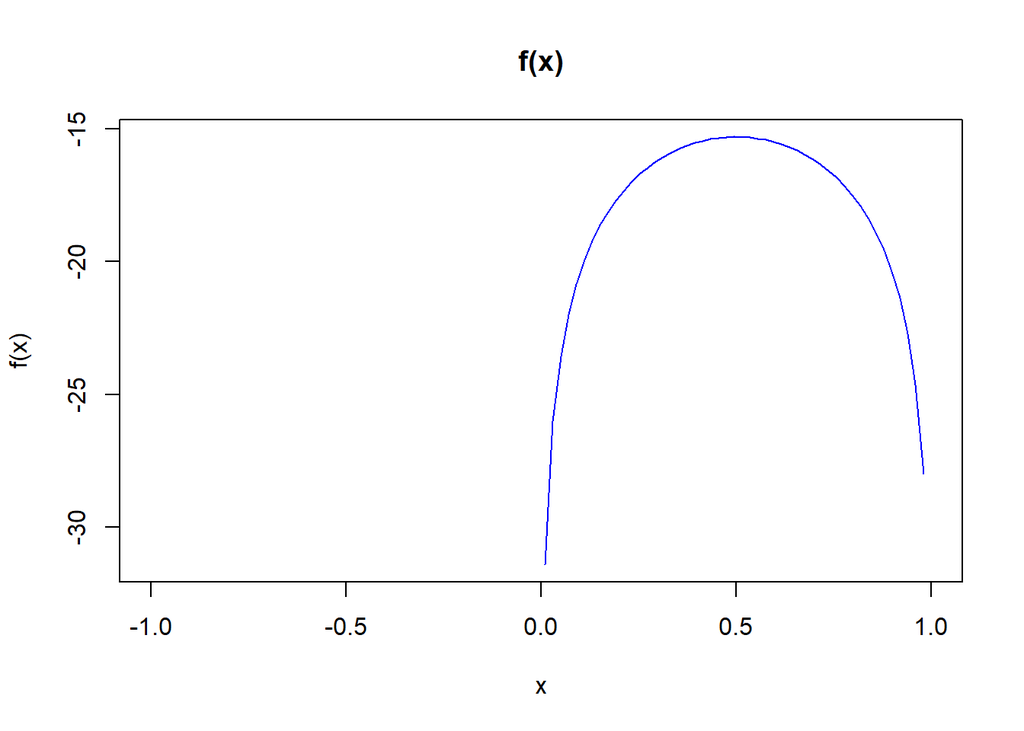

```r
x.vals = seq(-1,1,length.out=100)
plot(x.vals, loglike.exercise(x.vals), type="l", col="blue",
     xlab="x", ylab="f(x)", main="f(x)")
```

```r
# use maxLik function from maxLik package
# here function to compute log-likelihood returns log-likelihood values
# and not -1*log-likelihood values
library(maxLik)
theta.start = c(0.3)
names(theta.start) = c("theta")
theta.mle = maxLik(loglike.exercise, start=theta.start)
class(theta.mle)
```

```
## [1] "maxLik" "maxim"  "list"
```

```r
names(theta.mle)
```

```
##  [1] "maximum"    "estimate"   "gradient"   "hessian"    "code"
##  [6] "message"    "last.step"  "fixed"      "iterations" "type"
## [11] "control"
```

```r
theta.mle
```

```
## Maximum Likelihood estimation
## Newton-Raphson maximisation, 4 iterations
## Return code 1: gradient close to zero
## Log-Likelihood: -15.3 (1 free parameter(s))
## Estimate(s): 0.5
```

```r
summary(theta.mle)
```

```
## --------------------------------------------
## Maximum Likelihood estimation
## Newton-Raphson maximisation, 4 iterations
## Return code 1: gradient close to zero
## Log-Likelihood: -15.3
## 1  free parameters
## Estimates:
##       Estimate Std. error t value Pr(> t)
## theta    0.500      0.158    3.16  0.0016 **
## ---
## Signif. codes:  0 '***' 0.001 '**' 0.01 '*' 0.05 '.' 0.1 ' ' 1
## --------------------------------------------
```

## Solution to Exercise 2

**Maximum Likelihood Estimator in Logistic Regression**

```r
#The log likelihood defined as a function in the parameter and data
log.like <- function(beta0,beta1,x,y){
  p <- exp(beta0 + beta1*x)/(1+exp(beta0 + beta1*x))
  l <- sum(y*log(p) + (1-y)*log(1-p))
  return(l)
}

#The given data
x <- c(1.34, -1.38, -0.19, -0.44, 1.90, -0.80, 0.91, 0.26, 1.37, -1.62, -0.96, 1.90, 0.99, 1.96, -1.57, 1.51, -1.61, -1.02, -0.92, -1.87, 1.73, -1.23, -1.24, 0.22, 1.42)
y <- c(1, 0, 0, 1, 1, 0, 1, 1, 1, 0, 1, 1, 1, 1, 1, 0, 0, 0, 0, 0, 1, 0, 0, 1, 0)

#Likelihood at the given data
lbeta <- function(beta){log.like(beta[1],beta[2],x,y)}
```

The above chunks predefines all the useful function for our likelihood and stores the given data. Next we optimize the function in various cases as given in the problem.

**(a)** Use the function `optim()`to compute $\hat{{\bf{\beta}}}$ using initial value (.25,.75).

```r
#Part (a)
#Running the optim function but with a negative control
#This is to ensure maximization algorithm
obj <- optim(c(0.25,0.75),lbeta,control = list(fnscale = -1))
beta.hat <- obj$par
max.lik <- obj$value
```

Using initial value `(0.25,0.75)`, the estimated $\hat{\beta}$ is `(0.1159, 1.0286)` and the value of the log-likelihood at that point is `-13.0024`.

**(b)** Again, starting with (.25,.75) find the next value when using the Newton-Raphson algorithm.

We again start with the initial value `(0.25,0.75)`, to report the next value using the Newton-Raphson algorithm.

```r
#Part (b)

#Coding one iteration of the Newton Raphson procedure
library(numDeriv)
init <- c(0.25,0.75)
nr.grad <- grad(lbeta, init)
nr.hess <- hessian(lbeta, init)
update <- init - solve(nr.hess) %*% nr.grad

#Using the rootSolve package (alternate solution)
#install.packages("rootSolve")
library(rootSolve)
#Defining the derivatives of the likelihood functions
dlbeta <- function(beta){
  p <- exp(beta[1] + beta[2]*x)/(1+exp(beta[1] + beta[2]*x))
  dl <- c(sum(y - p),sum(x*(y - p)))
  return(dl)
}
#Solving the derivatives equal to zero
nr.roots <- multiroot(dlbeta, c(0.25,0.75), maxiter = 1)
```

The next value is `(0.1269, 0.9985)` by coding NR from scratch and `(0.1269, 0.9985)` by using `rootSolve` package.

**(c)** Assume that $\beta_{0}=0$, and plot the likelihood function $L(\beta_{1})$ as a function of $\beta_{1}$.

Assuming $\beta_0 = 0$, the plot of the likelihood function $L(\beta_1)$ as a function of $\beta_1$ is as follows.

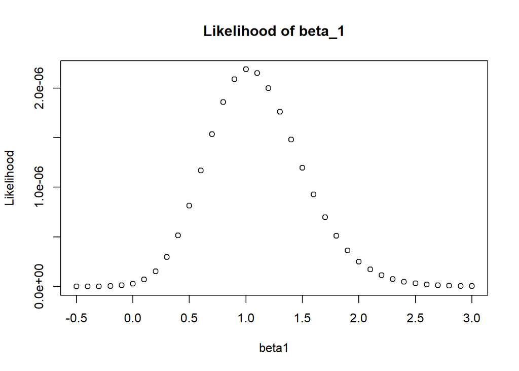

```r
#Part (c)
beta1 <- seq(-0.5,3,0.1)
lbeta1 <- sapply(beta1,function(beta){log.like(0,beta,x,y)})
plot(beta1,exp(lbeta1), main="Likelihood of beta_1", ylab="Likelihood")
```

**(d)** Again, assume $\beta_{0}=0$ and compute $\hat{\beta}_{1}$ using `uniroot()`, a grid search, and by the Newton-Raphson algorithm. You can use the plot in part (c) to find a good initial value.

We now find $\hat{\beta}_1$ by three different algorithms assuming $\beta_0 = 0$.

```r
#Part (d)
#By uniroot function in R
beta0 = 0
Lbeta1 <- function(beta){dlbeta(c(0,beta))[2]}
beta1.hat <- uniroot(Lbeta1, c(0,2))$root

#By grid search algorithm
grid = seq(0,2,0.001)
fun = sapply(grid,function(beta){log.like(0,beta,x,y)})
grid.beta1 = grid[fun == max(fun)]

#By Newton Raphson
NewtonRaph <- function(f,tol=1e-7,x0,N){
  h = 1e-7
  i = 1
  p = numeric(N)
  while(i <= N){
    dfdx <- (f(x0+h)-f(x0))/h
    x1 <- (x0-(f(x0)/dfdx))
    p[i] = x1
    i = i+1
    if(abs(x1-x0)<tol) break
    x0 = x1
  }
  return(p[1:(i-1)])
}
roots <- NewtonRaph(Lbeta1, x0 = 1, N = 1000)
#The final value
nr.beta1 <- roots[length(roots)]
```

We use `1` as the initial value of $\hat{\beta}_1$ according to the last plot. The `uniroot` estimate is `1.0219`, the grid search estimate is `1.022` and the N-R method esimate is `1.0219`.

## Solution to Exercise 3 (8.1)

We will implement the two-sample Cramer-von Mises test for equal distributions as a permutation test. Consider the `chickwts` dataset in R. We will test whether the distribution of `soybean` and `linseed` are equal or not. This data is discussed in Example `8.1` and `8.2`.

```r
data("chickwts")
attach(chickwts)
x <- sort(as.vector(weight[feed == "soybean"]))
y <- sort(as.vector(weight[feed == "linseed"]))
n1 <- length(x)
n2 <- length(y)
detach(chickwts)
#Defining the two-sample Cramer Von Mises test statistic as a function
cvmts.test <- function(x,y){
  nx <- length(x)
  ny <- length(y)
  sx <- ecdf(x)(x) - ecdf(y)(x)
  sy <- ecdf(x)(y) - ecdf(y)(y)
  return(nx*ny*(sum(sx^2)+sum(ny^2))/(nx+ny)^2)
}
#Performing the permutation test
R <- 999             #number of replicates
z <- c(x, y)         #pooled sample
K <- 1:(n1+n2)
reps <- numeric(R)   #storage for replicates
t0 <- cvmts.test(x, y)
for (i in 1:R) {
#generate indices k for the first sample
k <- sample(K, size = 14, replace = FALSE)
x1 <- z[k]
y1 <- z[-k]          #complement of x1
reps[i] <- cvmts.test(x1, y1)
}
p <- mean(c(t0, reps) >= t0)
```

The approximate ASL `0.664` does not support the alternative hypothesis that the distributions differ.

## Solution to Exercise 4 (9.2)

We again repeat the simulation of `Rayleigh`($\sigma = 4$) distribution as in `Example 9.1` of the book. But this time we use `Gamma`($X_t$,1) as the proposal distribution.

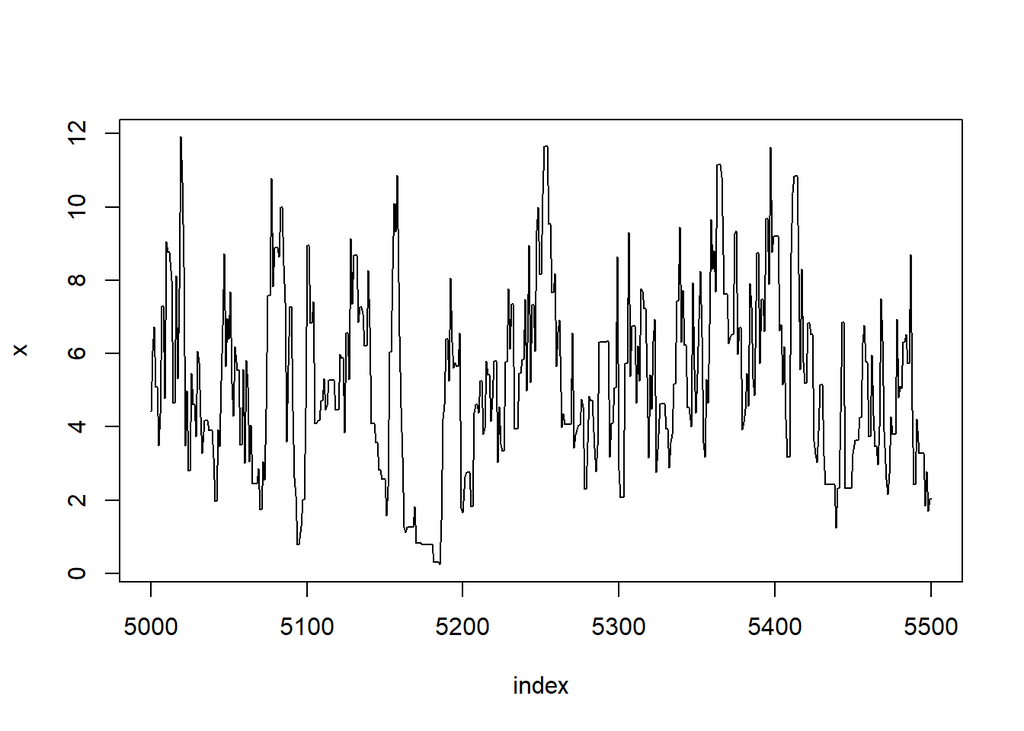

```r
f <- function(x, sigma){                      #function to evaluate the Rayleigh density
  if (any(x < 0)) return (0)
  stopifnot(sigma > 0)
  return((x / sigma^2) * exp(-x^2 / (2*sigma^2)))
}
m1 <- 10000
sigma <- 4
x <- numeric(m1)
x[1] <- rgamma(1, shape = 1, rate = 1)        #Starting from a (shape = 1) gamma
k1 <- 0
u <- runif(m1)
for (i in 2:m1) {
  xt <- x[i-1]
  y <- rgamma(1, shape = xt, rate = 1)        #Using chi square as the proposal distribution
  num <- f(y, sigma) * dgamma(xt, shape = y, rate = 1)
  den <- f(xt, sigma) * dgamma(y, shape = xt, rate = 1)
  if (u[i] <= num/den) x[i] <- y else {
    x[i] <- xt
    k1 <- k1+1                                  #y is rejected
  }
}
index <- 5000:5500
y1 <- x[index]
plot(index, y1, type="l", main="", ylab="x")
```

So in this simulation, approximately `30.88`% of the candidate points are rejected compared to the `40`% rejection rate for the simulation of `Rayleigh`($\sigma = 4$) using chi square distribution as the proposal distribution. Hence this is a more efficient simulation process (using gamma as the proposal distribution) that using chi square as done in the example. This is also evident from the less number of horizontal lines in the plot of the underlying stochastic process.

## Solution to Exercise 5 (9.4)

```r
Lden=function(x){
  return (1/2*exp(-abs(x)))
}

rw.Metropolis <- function(sigma, x0, N) {
x <- numeric(N)
x[1] <- x0
u <- runif(N)
k <- 0
for (i in 2:N) {
y <- rnorm(1, x[i-1], sigma)
if (u[i] <= (Lden(y) / Lden((x[i-1])))){
  x[i] <- y
  k=k+1
}
else {
x[i] <- x[i-1]
}
}
return(list(x=x, acrate=k/N))
}


N <- 2000
sigma <- c(.05, .5, 2, 16)
x0 <- 25 ###starting point
rw1 <- rw.Metropolis(sigma[1], x0, N)
rw2 <- rw.Metropolis(sigma[2], x0, N)
rw3 <- rw.Metropolis(sigma[3], x0, N)
rw4 <- rw.Metropolis(sigma[4], x0, N)
#number of candidate points rejected
print(c(rw1$acrate, rw2$acrate, rw3$acrate, rw4$acrate))
```

```
## [1] 0.9830 0.8370 0.5380 0.0805
```

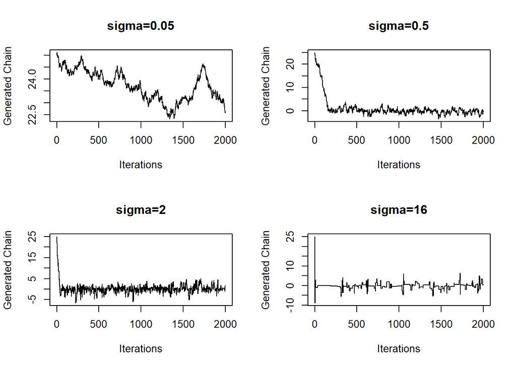

```r
#plot of generated chain
par(mfrow=c(2,2)) #'Four plot, one page'
plot(rw1$x,type='l',ylab='Generated Chain',xlab='Iterations',main='sigma=0.05')
plot(rw2$x,type='l',ylab='Generated Chain',xlab='Iterations',main='sigma=0.5')
plot(rw3$x,type='l',ylab='Generated Chain',xlab='Iterations',main='sigma=2')
plot(rw4$x,type='l',ylab='Generated Chain',xlab='Iterations',main='sigma=16')
```

```r
par(mfrow=c(1,1))#####set back to the 'one plot, one page'.
```

When the stargard deviation of our move is getting larger, the acceptance rate is getting lower. Generally, we don’t want very high acceptance rate because it indicates the move is too sticky. Then, it will not converge when the number of iterations in generated chain is not large enough. But, we also don’t want too low acceptance rate. Too low acceptance rate will decrease the efficiency of our algorithm. In this case, ‘sigma=2’ seems good enough for us to be our proposal.

## Solution to Exercise 6 (9.7)

If $(X,Y) \sim Nomral( \begin{bmatrix} \mu_1 \\ \mu_2 \end{bmatrix}, \begin{bmatrix} \sigma_{1}^2,\rho \sigma_1 \sigma_2\\ \rho \sigma_1 \sigma_2,\sigma_2^2 \end{bmatrix} )$, the conditional distribution is:

$$(X|Y=y) \sim Normal(\mu_1+\rho \frac{\sigma_1}{\sigma_2}(y-\mu_2),(1-\rho^2)\sigma_1^2)$$
$$(Y|X=x) \sim Normal(\mu_2+\rho \frac{\sigma_2}{\sigma_1}(x-\mu_1),(1-\rho^2)\sigma_2^2)$$

Thus, to generate (X,Y), we can generate X and Y from X|Y and Y|X iteratively based on gibbs sampling.

In this question, $\mu_1=0, \mu_2=0, \sigma_1=1, \sigma_2=1, \rho=0.9$.

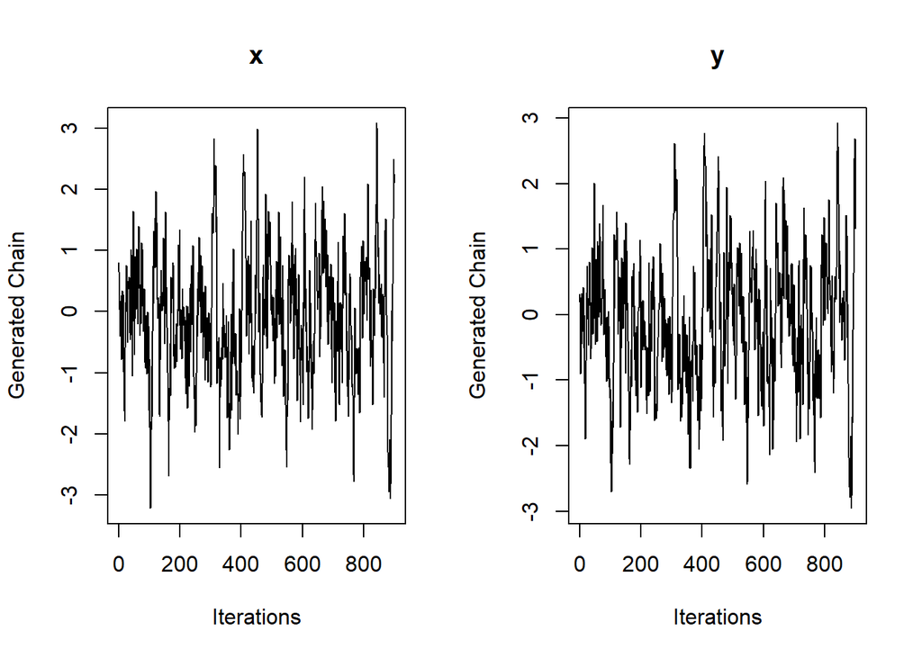

```r
x1=10   ##inital point of generated sample
burn=100 ##burn-in period
N=1000 ##chain length
x=numeric(N)
y=numeric(N)
x[1]=x1
for (i in 1:N){
  if (i==1){
    y[1]=rnorm(1,0.9*x[1],sqrt(1-0.9^2))
  }
  else{
    x[i]=rnorm(1,0.9*y[i-1],sqrt(1-0.9^2))
    y[i]=rnorm(1,0.9*x[i],sqrt(1-0.9^2))
  }
}
xsample=x[(burn+1):N]
ysample=y[(burn+1):N]
##plot generated chain of x and y
par(mfrow=c(1,2)) #'Four plot, one page'
plot(xsample,type='l',ylab='Generated Chain',xlab='Iterations',main='x')
plot(ysample,type='l',ylab='Generated Chain',xlab='Iterations',main='y')
```

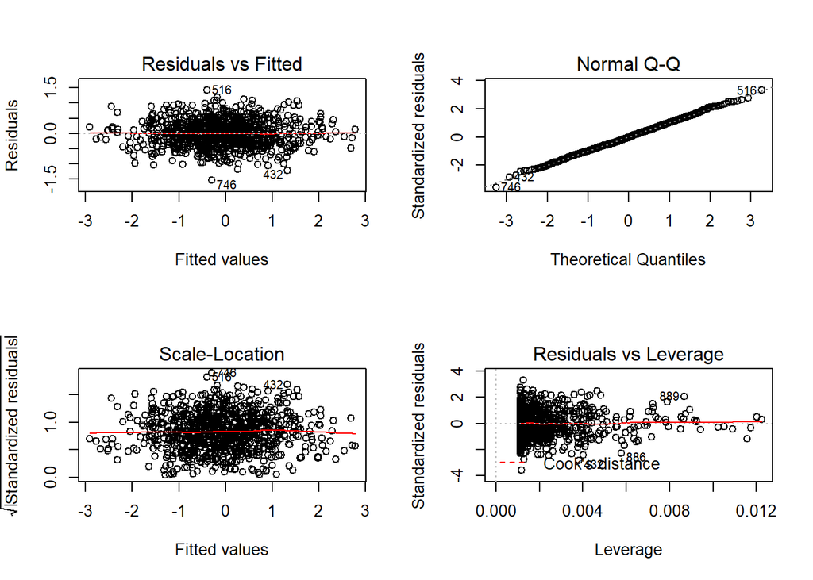

```r
par(mfrow=c(1,1))#####set back to the 'one plot, one page'

##fit sample based on regression
modelfit=lm(ysample~xsample)
res=modelfit$residuals #residuals
#check normality and constant variance
par(mfrow=c(2,2))
plot(modelfit)
```

```r
par(mfrow=c(1,1))
```

From the residual plot and qq plot, we find residuals can indicate the normality and constant variance in the regression model.

## Solution to Exercise 7 (9.8)

Consider the bivariate density

$$f(x,y) \propto \binom{n}{x} \; y^{x+a-1} \; (1-y)^{n-x+b-1}, \quad x = 0,1,\ldots, n, \; 0 \le y \le 1.$$
It is given that the conditional distributions are `Binomial(n,y)` and `Beta(x+a, n-x+b)` for some fixed `a,b,n`. We write the following function to generate a chain with target joint density `f(x,y)` using the Gibbs sampler.

```r
gibbs.sim <- function(n,a,b){
  #initialize constants and parameters
  N <- 5000                           #length of chain
  burn <- 1000                        #burn-in length
  X <- matrix(0, N, 2)                #the chain, a bivariate sample
  ###### generate the chain #####
  X[1, ] <- c(floor(n/2), a/(a+b))    #initialize with arbitrary seed
  for (i in 2:N){
    x2 <- X[i-1, 2]
    X[i, 1] <- rbinom(1, n, x2)
    x1 <- X[i, 1]
    X[i, 2] <- rbeta(1, x1+a, n-x1+b)
  }
  b <- burn + 1
  sample.g <- X[b:N, ]
  return(sample.g)
}
```

This function `gibbs.sim` returns `sample.g` which is the generated chain from the target joint density.

## Solution to Exercise 8 (9.10)

```r
#Defining the function to calculate the G-R statistic
Gelman.Rubin <- function(psi){
  # psi[i,j] is the statistic psi(X[i,1:j])
  # for chain in i-th row of X
  psi <- as.matrix(psi)
  n <- ncol(psi)
  k <- nrow(psi)
  psi.means <- rowMeans(psi)     #row means
  B <- n * var(psi.means)        #between variance est.
  psi.w <- apply(psi, 1, "var")  #within variances
  W <- mean(psi.w)               #within est.
  v.hat <- W*(n-1)/n + (B/n)     #upper variance est.
  r.hat <- v.hat / W             #G-R statistic
  return(r.hat)
}

f <- function(x, sigma){         #function to evaluate the Rayleigh density
  if (any(x < 0)) return (0)
  stopifnot(sigma > 0)
  return((x / sigma^2) * exp(-x^2 / (2*sigma^2)))
}
k <- 4                           #number of chains to generate
sigma <- 4
x <- as.matrix(c(0.01, 2, 4, 6)) #initializing with overdispersed values
ral.chain <- function(x){        #defining a function to generate one iteration of the chains
  xi <- numeric(nrow(x))
  for(i in 1:length(xi)){
    xt <- x[i, ncol(x)]
    y <- rchisq(1, df = xt)      #Using chi square as the proposal distribution
    num <- f(y, sigma) * dchisq(xt, df = y)
    den <- f(xt, sigma) * dchisq(y, df = xt)
    u <- runif(1)
    if (u <= num/den) xi[i] <- y else{
      xi[i] <- xt                #y is rejected
    }
  }
  return(cbind(x,xi))
}
r.hat = 10
while(r.hat >= 1.2){             #continuing the chain till it converges
  x <- ral.chain(x)
  psi <- t(apply(x, 1, cumsum))
  for (i in 1:nrow(psi))
    psi[i,] <- psi[i,] / (1:ncol(psi))
  r.hat <- Gelman.Rubin(psi)
}
b <- ncol(x)                     #Denotes when the chain was confirmed to have converged

#now using the coda package to check convergence by the G-R method
install.packages("coda")
library(coda)
x.mcmc <- mcmc.list(as.mcmc(x[1,]),as.mcmc(x[2,]),as.mcmc(x[3,]),as.mcmc(x[4,]))
geweke.diag(x.mcmc)
geweke.plot(x.mcmc)
```

[output not shown]

The `Gelman.Rubin` function gives the G-R convergence diagnostic statistic for the MCMC chain. We see that our chains converge at `b=572`, by the constraint $\hat{R} < 1.2$. We also verify this convergence by the `geweke.diag` function from the `coda` package. We see that the Z-statistic values are `-1.8711, -0.1328, -1.1570, -0.5999`, all of which are greater than `-1.96` and hence indicate convergence.